# HTE Analysis for the EOLIA trial using BART

## Introduction

This R Markdown file estimates the heterogeneous treatment effects (HTE) using Bayesian Additive Regression Trees (BART) for the EOLIA trial.

The workflow includes 2 main steps:

1. Estimation of Conditional Average Treatment Effects (CATE) using BART.
2. “Fit-the-fit” approach with classification and regression trees (CART) to identify covariate-defined subgroups’ differential treatment effects.

## Data Preprocessing

```r
# Load the dataset
load("../../../data/EOLIA_04122017/eolia_form.RData")

# Clean up variable types and remove rows with missing data
dat <- eolia[, c("age", "sexe", "ards_etiology_regroup3",
                 "pao2_fio2_rando", "paco2_rando",
                 "vasopressors_rando", "prone_rando", "manoeuvre_rando",
                 "steroid_rando", "sepsis_class_bin", "immunocomp_adm",
                 "lactate_rando", "rrt_rando", "sofa_rando_bin", "del_intub_rando_bin",
                 "compliance_rando", "driving_rando",
                 "ecmo_centers.f",
                 "bras_en", "statut_vital_j60")]

addmargins(table(dat$bras_en, dat$statut_vital_j60))
```

```
##
##             0   1 Sum
##   ECMO     80  44 124
##   Control  68  57 125
##   Sum     148 101 249
```

```r
cat("Number of missing observations for each variables:\n")
```

```
## Number of missing observations for each variables:
```

```r
sapply(dat, function(x) sum(is.na(x)))
```

```
##                    age                   sexe ards_etiology_regroup3
##                      0                      0                      0
##        pao2_fio2_rando            paco2_rando     vasopressors_rando
##                      1                      1                      0
##            prone_rando        manoeuvre_rando          steroid_rando
##                      0                      0                      0
##       sepsis_class_bin         immunocomp_adm          lactate_rando
##                      0                      1                     13
##              rrt_rando         sofa_rando_bin    del_intub_rando_bin
##                      0                      0                      0
##       compliance_rando          driving_rando         ecmo_centers.f
##                     58                     58                      0
##                bras_en       statut_vital_j60
##                      0                      0
```

```r
cat("Suppression of compliance and driving pressure variables (too many missing values): \n")
```

```
## Suppression of compliance and driving pressure variables (too many missing values):
```

```r
dat$compliance_rando <- dat$driving_rando <- NULL
dat <- dat[complete.cases(dat), ] # rows without missing values
dat$pao2_fio2_rando <- round(dat$pao2_fio2_rando)

cat("Number of observations in the EOLIA database: ", nrow(eolia), "\n")
```

```
## Number of observations in the EOLIA database:  249
```

```r
cat("Number of observations in the analysis database: ", nrow(dat), "\n")
```

```
## Number of observations in the analysis database:  235
```

```r
addmargins(table(dat$bras_en, dat$statut_vital_j60))
```

```
##
##             0   1 Sum
##   ECMO     73  43 116
##   Control  64  55 119
##   Sum     137  98 235
```

```r
# Impute NA values in a character column "adlmorelessf" with the mode
impute_mode <- function(column) {
  mode_value <- names(which.max(table(column, useNA = "no")))
  column[is.na(column)] <- mode_value
  return(column)
}

# Replace NA values with the median of each numerical column
impute_with_median <- function(x) {
  apply(x, 2, function(col) {
    col[is.na(col)] <- median(col, na.rm = TRUE)
    return(col)
  })
}

# Print out summaries of continuous covariates pre-standardization
cat("Mean and SD of age (pre-standardization):\n")
```

```
## Mean and SD of age (pre-standardization):
```

```r
cat("Mean:", mean(dat$age, na.rm = TRUE), "\n")
```

```
## Mean: 53.14894
```

```r
cat("SD:", sd(dat$age, na.rm = TRUE), "\n")
```

```
## SD: 13.63219
```

```r
cat("Mean and SD of PaO2/FiO2 (pre-standardization):\n")
```

```
## Mean and SD of PaO2/FiO2 (pre-standardization):
```

```r
cat("Mean:", mean(dat$pao2_fio2_rando, na.rm = TRUE), "\n")
```

```
## Mean: 72.8766
```

```r
cat("SD:", sd(dat$pao2_fio2_rando, na.rm = TRUE), "\n")
```

```
## SD: 27.47411
```

```r
cat("Mean and SD of PaCO2 (pre-standardization):\n")
```

```
## Mean and SD of PaCO2 (pre-standardization):
```

```r
cat("Mean:", mean(dat$paco2_rando, na.rm = TRUE), "\n")
```

```
## Mean: 56.77447
```

```r
cat("SD:", sd(dat$paco2_rando, na.rm = TRUE), "\n")
```

```
## SD: 15.39245
```

```r
cat("Mean and SD of Lactate (pre-standardization):\n")
```

```
## Mean and SD of Lactate (pre-standardization):
```

```r
cat("Mean:", mean(dat$lactate_rando, na.rm = TRUE), "\n")
```

```
## Mean: 2.837021
```

```r
cat("SD:", sd(dat$lactate_rando, na.rm = TRUE), "\n")
```

```
## SD: 2.795041
```

```r
# Standardize continuous covariates
contvar_unscaled <- dat[, c("age", "pao2_fio2_rando", "paco2_rando", "lactate_rando")]
dat$age <- (dat$age - mean(dat$age)) / sd(dat$age)
dat$pao2_fio2_rando <- (dat$pao2_fio2_rando - mean(dat$pao2_fio2_rando)) / sd(dat$pao2_fio2_rando)
dat$paco2_rando <- (dat$paco2_rando - mean(dat$paco2_rando)) / sd(dat$paco2_rando)
dat$lactate_rando <- (dat$lactate_rando - mean(dat$lactate_rando)) / sd(dat$lactate_rando)

# Treatment variable as logical
dat$bras_en <- ifelse(dat$bras_en == "ECMO", TRUE, FALSE)

# Rename covariates for easier use in decision tree plotting
colnames(dat) <- c("Age", "Sexe", "ARDS etiology", "PaO2/FiO2", "PaCO2",
                        "Vasopressors", "Prone position", "Recruitment maneuvers",
                        "Corticosteroids", "Severe sepsis or septic shock",
                        "Immunocompromised", "Lactate", "Renal replacement therapy",
                        "SOFA score", "Interval between start on MV and randomization",
                        "Center",
                        "z", "dead60")

# Check the updated data structure
head(dat)
```

```
##          Age Sexe       ARDS etiology  PaO2/FiO2       PaCO2 Vasopressors
## 1 -0.5977715  Man Bacterial pneumonia -0.3230895 -0.57005009           No
## 2 -1.1846176  Man               Other -1.2694351  0.07961902          Yes
## 3  1.5295458  Man               Other  0.8052456  1.24902342          Yes
## 4  0.4292093  Man Bacterial pneumonia -0.5414769 -0.11528171          Yes
## 5 -0.8911945  Man               Other -0.1047021  0.46942049           No
## 7  0.2824977  Man               Other  0.9508372  0.33948667          Yes
##   Prone position Recruitment maneuvers Corticosteroids
## 1             No                    No              No
## 2             No                    No              No
## 3            Yes                    No              No
## 4             No                    No              No
## 5             No                   Yes              No
## 7             No                    No              No
##   Severe sepsis or septic shock Immunocompromised    Lactate
```

[output cut: 20 more lines]

### Step 1: Estimating CATE using BART

```r
bart_fit <- function(X, y, z, seed = 60622, nfolds = 10,
                          Power = 1:3, Base = c(0.25, 0.5, 0.95), Ntrees = c(50, 200, 400),
                          nchains = 4, keepevery = 1, nskip = 500){

  # Predictors: combine treatment indicator z with covariates X
  x <- cbind(z, X)

  # Create datasets under counterfactual treatment scenarios (z = TRUE and z = FALSE)
  x1 <- x0 <- x
  x1$z <- TRUE
  x0$z <- FALSE

  ## Cross-validation step for hyperparameter tuning (Power, Base, Ntrees)
  if (length(Power) * length(Base) * length(Ntrees) > 1) {

    # Create dataset folds for cross-validation
    set.seed(seed)
    folds <- createFolds(y, k = nfolds, list = TRUE, returnTrain = FALSE)

    # Initialize output matrices for prediction error from each model
    cvoutput <- expand.grid(Power, Base, Ntrees, NA)
    colnames(cvoutput) <- c("Power", "Base", "Ntrees", "CVMSE")
    mse <- array(NA, dim = c(nrow(cvoutput), nfolds))

    # Perform cross-validation for hyperparameter tuning  (may take >2 hours)
    for (hp in 1:nrow(cvoutput)) {
      for (i in 1:nfolds) {

        # Fit BART model with specific hyperparameters
        set.seed(seed + (hp - 1) * nfolds + i)
        bartmod <- lbart.cluster(x.train = x[-folds[[i]],],
                             y.train = y[-folds[[i]]],
                             x.test = x[folds[[i]],],
                             power = cvoutput$Power[hp],
                             base = cvoutput$Base[hp],
                             ntree = cvoutput$Ntrees[hp], nchains = nchains,
                             nskip=nskip, keepevery = keepevery)

        # Predictions and MSE calculation
        bartmod$yhat.test.collapse <- apply(bartmod$yhat.test, 2, rbind)
        pred <- exp(colMeans(bartmod$yhat.test.collapse)) /
                (1 + exp(colMeans(bartmod$yhat.test.collapse)))
        mse[hp, i] <- mean((y[folds[[i]]] - pred)^2)
      }
    }

    # Calculate cross-validation error (CVMSE) for each hyperparameter combination
    cvoutput$CVMSE <- rowMeans(mse)

    # Fit final model with best hyperparameters based on minimum CVMSE
    set.seed(seed)
    best_hp <- which.min(cvoutput$CVMSE)
    bartmod1 <- lbart.cluster(x.train = x, y.train = y,
                              x.test = x1, nchains = nchains,
                              power = cvoutput$Power[best_hp],
                              base = cvoutput$Base[best_hp],
                              ntree = cvoutput$Ntrees[best_hp],
                              nskip=nskip, keepevery = keepevery)

    set.seed(seed + 1)
    bartmod0 <- lbart.cluster(x.train = x, y.train = y,
                              x.test = x0, nchains = nchains,
                              power = cvoutput$Power[best_hp],
                              base = cvoutput$Base[best_hp],
                              ntree = cvoutput$Ntrees[best_hp],
                              nskip=nskip, keepevery = keepevery)

    # Print the optimal hyperparameters for future reference
    cat("Optimal hyperparameters index:", best_hp,"\n")
    cat("Power", "Base", "Ntrees:", "\n")
    cat(cvoutput[best_hp, 1], cvoutput[best_hp, 2], cvoutput[best_hp, 3],"\n")

  }else{
    # Fit BART model directly with pre-specified hyperparameters if no cross-validation needed
    set.seed(seed)
    bartmod1 <- lbart.cluster(x.train = x, y.train = y,
                              x.test = x1, nchains = nchains,
                              power = Power,
                              base = Base,
                              ntree = Ntrees,
                              nskip=nskip, keepevery = keepevery)

    set.seed(seed + 1)
    bartmod0 <- lbart.cluster(x.train = x, y.train = y,
                              x.test = x0, nchains = nchains,
                              power = Power,
                              base = Base,
                              ntree = Ntrees,
                              nskip=nskip, keepevery = keepevery)
  }

  # Collapse predictions across chains for certain calculations
  bartmod1$yhat.test.collapse <- apply(bartmod1$yhat.test, 2, rbind)
  bartmod0$yhat.test.collapse <- apply(bartmod0$yhat.test, 2, rbind)
  bartmod1$yhat.train.collapse <- apply(bartmod1$yhat.train, 2, rbind)
  bartmod0$yhat.train.collapse <- apply(bartmod0$yhat.train, 2, rbind)

  # Transform the fitted outcomes to probabilities using inverse logit transformation
  prob_treated <- exp(bartmod1$yhat.test.collapse) / (1 +   exp(bartmod1$yhat.test.collapse))
  prob_control <- exp(bartmod0$yhat.test.collapse) / (1 + exp(bartmod0$yhat.test.collapse))

  # Calculate the CATE (risk difference) for each individual for each MCMC sample
  cate_posterior <- prob_treated - prob_control

  # Calculate the Risk Ratio (RR) for each individual for each MCMC sample
  # Add small constant to avoid division by zero
  epsilon <- 1e-10
  rr_posterior <- prob_treated / (prob_control + epsilon)

  # Compute the mean CATE across all MCMC samples
  cate <- apply(cate_posterior, 2, mean)

  # Compute the mean RR across all MCMC samples
  rr <- apply(rr_posterior, 2, mean)

  # Calculate equal-tailed 95% credible intervals for CATE
  res <- data.frame(
    # Risk Difference metrics
    cate = cate,
    cate_lower = apply(cate_posterior, 2, quantile, probs = 0.025),
    cate_upper = apply(cate_posterior, 2, quantile, probs = 0.975),

    # Risk Ratio metrics
    rr = rr,
    rr_lower = apply(rr_posterior, 2, quantile, probs = 0.025),
    rr_upper = apply(rr_posterior, 2, quantile, probs = 0.975),

    # Expected probabilities under each treatment
    prob_treated_mean = apply(prob_treated, 2, mean),
    prob_control_mean = apply(prob_control, 2, mean))

  return(list(
    cate_results = res,
    bartmod0 = bartmod0,
    bartmod1 = bartmod1,
    # posterior distributions
    cate_posterior = cate_posterior,
    rr_posterior = rr_posterior
  ))
}
```

##### Plot: Estimated CATEs (solid line) with 95% Credible Intervals (shaded area) for each individual

```r
plot_treatment_effects <- function(cate.res) {
  library(gridExtra)

  # Sort by CATE for risk difference plot
  cate.res.sorted <- cate.res[order(cate.res$cate, decreasing = TRUE), ]
  cate.res.sorted$index <- 1:nrow(cate.res.sorted)

  # Risk Difference Plot
  p1 <- ggplot(cate.res.sorted, aes(x = index, y = cate)) +
    geom_ribbon(aes(ymin = cate_lower, ymax = cate_upper),
                fill = "grey", alpha = 0.4) +
    geom_line(linewidth = 1) +
    geom_hline(yintercept = 0, lty = 3, color = "red") +
    xlab("Participant (sorted by risk difference)") +
    ylab("Risk Difference") +
    theme_bw()

  # Sort by RR for risk ratio plot
  cate.res.sorted2 <- cate.res[order(cate.res$rr, decreasing = TRUE), ]
  cate.res.sorted2$index <- 1:nrow(cate.res.sorted2)

  # Risk Ratio Plot
  p2 <- ggplot(cate.res.sorted2, aes(x = index, y = rr)) +
    geom_ribbon(aes(ymin = rr_lower, ymax = rr_upper),
                fill = "lightblue", alpha = 0.4) +
    geom_line(linewidth = 1) +
    geom_hline(yintercept = 1, lty = 3, color = "red") +
    xlab("Participant (sorted by risk ratio)") +
    ylab("Risk Ratio") +
    theme_bw() +
    scale_y_continuous(trans = "log",
                       breaks = c(0.25, 0.5, 1, 2, 4),
                       labels = c("0.25", "0.5", "1", "2", "4"))

  # Combine plots
  grid.arrange(p1, p2, ncol = 1)
}
```

#### Binary Outcome

```r
# Set up variables for the model
z <- dat[, "z"]  # Binary treatment variable
y <- dat[, "dead60"]  # Outcome variable (dead60)
X <- dat[, !(names(dat) %in% c("z", "dead60"))]  # Covariates

X_unscaled <- X
X_unscaled$Age <- contvar_unscaled$age
X_unscaled$`PaO2/FiO2` <- contvar_unscaled$pao2_fio2_rando
X_unscaled$PaCO2 <- contvar_unscaled$paco2_rando
X_unscaled$Lactate <- contvar_unscaled$lactate_rando

# Hyperparameter values selected via cross-validation
cvresults_mort <- c(3, 0.25, 400)  # Power, Base, Ntrees

# Fit the BART model
step1.res <- bart_fit(X, y, z,
                      Power  = cvresults_mort[1],
                      Base   = cvresults_mort[2],
                      Ntrees = cvresults_mort[3])
```

```
## [1]  744 4148 3964   18
## [1] 2982 2379 8349 1086
```

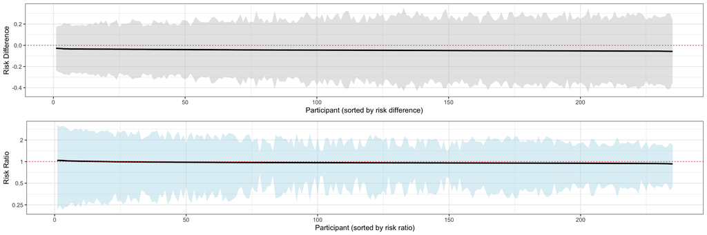

```r
cate.res = step1.res$cate_results
bartmod0 = step1.res$bartmod0
bartmod1 = step1.res$bartmod1

# Create visualization with both metrics
plot_treatment_effects(cate.res)
```

```r
ate_draws_rd <- rowMeans(step1.res$cate_posterior)
ate_draws_rr <- rowMeans(step1.res$rr_posterior)

ate_df <- data.frame(
  Metric = c("Posterior Mean", "95% CrI lower", "95% CrI upper"),
  Risk_Difference = c(
    mean(ate_draws_rd),
    quantile(ate_draws_rd, 0.025),
    quantile(ate_draws_rd, 0.975)
  ),
  Risk_Ratio = c(
    mean(ate_draws_rr),
    quantile(ate_draws_rr, 0.025),
    quantile(ate_draws_rr, 0.975)
  )
)

ind_df <- data.frame(
  Metric = c("Mean", "SD", "IQR lower (25th pctl)", "IQR upper (75th pctl)",
             "Min", "Max", "Prop. RD>0 (RR>1)"),
  Risk_Difference = c(
    mean(cate.res$cate),
    sd(cate.res$cate),
    quantile(cate.res$cate, 0.25),
    quantile(cate.res$cate, 0.75),
    min(cate.res$cate),
    max(cate.res$cate),
    mean(cate.res$cate > 0)
  ),
  Risk_Ratio = c(
    mean(cate.res$rr),
    sd(cate.res$rr),
    quantile(cate.res$rr, 0.25),
    quantile(cate.res$rr, 0.75),
    min(cate.res$rr),
    max(cate.res$rr),
    mean(cate.res$rr > 1)
  )
)

knitr::kable(ate_df, digits = 4,
             col.names = c("", "Risk Difference", "Risk Ratio"),
             caption = "Average CATE among all patients")
```

Average CATE among all patients

|  |  | Risk Difference | Risk Ratio |
| --- | --- | --- | --- |
|  | Posterior Mean | -0.0462 | 0.9673 |
| 2.5% | 95% CrI lower | -0.1602 | 0.6832 |
| 97.5% | 95% CrI upper | 0.0696 | 1.3640 |

```r
knitr::kable(ind_df, digits = 4,
             col.names = c("", "Risk Difference", "Risk Ratio"),
             caption = "Individual CATE (posterior means across patients) summary")
```

Individual CATE (posterior means across patients) summary

|  | Risk Difference | Risk Ratio |
| --- | --- | --- |
| Mean | -0.0462 | 0.9673 |
| SD | 0.0062 | 0.0204 |
| IQR lower (25th pctl) | -0.0513 | 0.9532 |
| IQR upper (75th pctl) | -0.0415 | 0.9764 |
| Min | -0.0573 | 0.9295 |
| Max | -0.0279 | 1.0404 |
| Prop. RD>0 (RR>1) | 0.0000 | 0.0851 |

### Step 2: “Fit-the-Fit” Approach with Classification and Regression Trees (CART) Model for CATE Subgroup Identification

In the second stage, the “fit-the-fit” approach is used to find subgroups exhibiting heterogeneity of treatment effect. In particular, a CART model is fit with the estimated CATE values from the first stage as the outcome and the covariates as possible predictors.

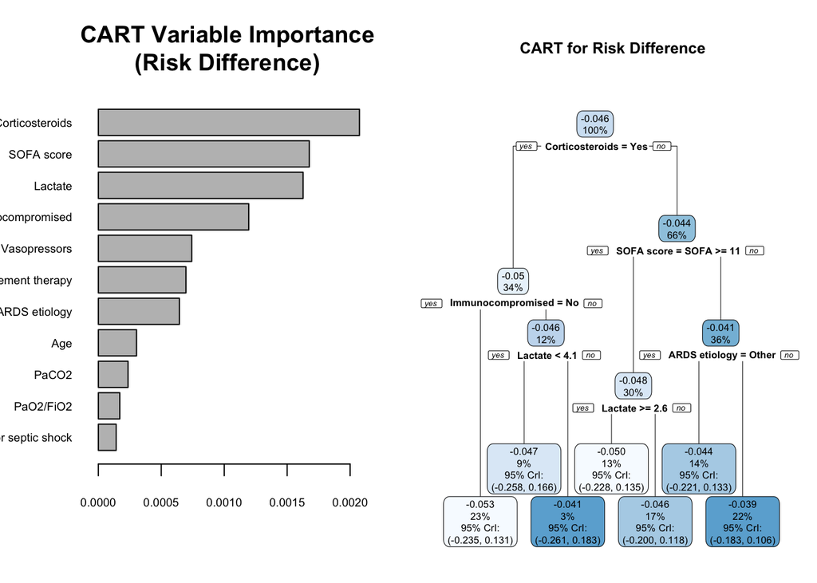

```
##
## ==== RISK DIFFERENCE SUBGROUPS ====
##
## Node: 13   n = 52
##   Mean Risk Difference : -0.039
##   95% Posterior CrI for Subgroup Mean: [ -0.183 , 0.106 ]
##
## Node: 10   n = 39
##   Mean Risk Difference : -0.046
##   95% Posterior CrI for Subgroup Mean: [ -0.2 , 0.118 ]
##
## Node: 9   n = 31
##   Mean Risk Difference : -0.05
##   95% Posterior CrI for Subgroup Mean: [ -0.228 , 0.135 ]
##
## Node: 12   n = 32
##   Mean Risk Difference : -0.044
##   95% Posterior CrI for Subgroup Mean: [ -0.221 , 0.133 ]
##
## Node: 3   n = 53
##   Mean Risk Difference : -0.053
##   95% Posterior CrI for Subgroup Mean: [ -0.235 , 0.131 ]
##
## Node: 5   n = 21
##   Mean Risk Difference : -0.047
##   95% Posterior CrI for Subgroup Mean: [ -0.258 , 0.166 ]
##
## Node: 6   n = 7
##   Mean Risk Difference : -0.041
##   95% Posterior CrI for Subgroup Mean: [ -0.261 , 0.183 ]
```

```r
cart_fit <- function(point_est, posterior, X,
                               maxdepth = 3, cp = 0.01,
                               metric = c("Risk Difference", "Risk Ratio"),
                               digits = 3) {
  ## point_est  : length-n vector of per-patient posterior-mean CATEs (RD or RR)
  ## posterior  : (n_draws x n_patients) matrix of posterior draws (same scale)
  ## X           : data.frame of covariates for CART splits
  ## metric      : label for titles and printed output

  metric <- match.arg(metric)

  stopifnot(ncol(posterior) == length(point_est))
  stopifnot(nrow(X) == length(point_est))

  n_total <- length(point_est)

  data_cart <- data.frame(X, outcome = point_est, check.names = FALSE)
  cartmod <- rpart(
    outcome ~ ., data = data_cart, method = "anova",
    control = rpart.control(cp = cp, maxdepth = maxdepth),
    model = TRUE
  )

  ## Precompute posterior CrI for terminal nodes only
  frame <- cartmod$frame
  node_info <- vector("list", nrow(frame))

  for (i in seq_len(nrow(frame))) {
    if (frame$var[i] != "<leaf>") next
    idx <- which(cartmod$where == i)
    if (length(idx) == 0) next
    node_avg_draws <- rowMeans(posterior[, idx, drop = FALSE])
    node_info[[i]] <- list(
      mean = mean(node_avg_draws),
      lo   = quantile(node_avg_draws, 0.025),
      hi   = quantile(node_avg_draws, 0.975),
      n    = length(idx),
      pct  = round(100 * length(idx) / n_total)
    )
  }

  ## Custom node label: CrI only for leaves, default for internal nodes
  node_label <- function(x, labs, digits, varlen) {
    fr <- x$frame
    for (i in seq_along(labs)) {
      if (fr$var[i] == "<leaf>" && !is.null(node_info[[i]])) {
        info <- node_info[[i]]
        labs[i] <- sprintf("%s\n%d%%\n95%% CrI:\n(%s, %s)",
                           formatC(info$mean, format = "f", digits = 3),
                           info$pct,
                           formatC(info$lo,   format = "f", digits = 3),
                           formatC(info$hi,   format = "f", digits = 3))
      }
    }
    labs
  }

  ## Variable importance
  barplot(sort(cartmod$variable.importance), horiz = TRUE, las = 1,
          cex.names = 0.6, cex.axis = 0.6,
          main = paste0("CART Variable Importance\n(", metric, ")"))

  ## Tree with CrI labels
  rpart.plot(cartmod,
             main = paste("CART for", metric),
             yesno = 2,
             node.fun = node_label)

  ## Printed summaries
  cat("\n====", toupper(metric), "SUBGROUPS ====\n")
  for (i in unique(cartmod$where)) {
    idx <- which(cartmod$where == i)
    node_avg_draws <- rowMeans(posterior[, idx, drop = FALSE])
    node_mean <- mean(node_avg_draws)
    node_ci   <- quantile(node_avg_draws, c(0.025, 0.975))
    cat("\nNode:", i, "  n =", length(idx), "\n")
    cat("  Mean", metric, ":", round(node_mean, digits), "\n")
    cat("  95% Posterior CrI for Subgroup Mean: [",
        round(node_ci[1], digits), ",", round(node_ci[2], digits), "]\n")
  }

  invisible(cartmod)
}

par(mfrow = c(1, 2))
cart_rd <- cart_fit(
  point_est = cate.res$cate,
  posterior = step1.res$cate_posterior,
  X         = X_unscaled,
  metric    = "Risk Difference",
  maxdepth = 3, cp = 0.01, digits = 3
)
```

```r
cart_rr <- cart_fit(
  point_est = cate.res$rr,
  posterior = step1.res$rr_posterior,
  X         = X_unscaled,
  metric    = "Risk Ratio",
  maxdepth = 3, cp = 0.01, digits = 3
)
```

[figure not shown]

[output not shown]

```r
par(mfrow = c(1, 1))
```

### VIVI-VSUP

Inglis et al. (2024) employ Value Suppressing Uncertainty Palettes (VSUP) to construct heatmaps that jointly display variable importance (VImp) and variable interactions (VInt) (collectively referred to as VIVI) using color scale to represent posterior uncertainty.

In the analysis below, we take the estimated conditional average treatment effects from Stage 1 and regress them on covariates alone by fitting a new BART model. This second-stage BART fit is used to identify which covariates are predictive of treatment effect heterogeneity. The resulting VIVI–VSUP heatmap summarizes variable importance and interactions from this model: diagonal elements correspond to marginal variable importance, while off-diagonal elements represent pairwise interaction strength. Color intensity reflects magnitude, and desaturation/lightness encodes posterior uncertainty (here we use the coefficient of variation, following the bartMan package author’s preference).

```r
zip <- bartMan:::zip

# scaled covariates matrix: expanding factors to a set of dummy variables
X_mat <- model.matrix(~ ., data = X)[, -1]

# create dbarts model
set.seed(123)
dbart_cate_rd <- bart(
    x.train = X_mat,
    y.train = cate.res$cate,
    ntree = 50,
    ndpost = 500,
    nskip = 200,
    keeptrees = TRUE
)

# Create data frames
fData_rd <- as.data.frame(cbind(X_mat, cate.est = cate.res$cate))
trees_data_rd <- extractTreeData(model = dbart_cate_rd, data = fData_rd)
```

```
## Generating Child/Parent Mappings:
```

```
## Extracting Observation Data...
```

```r
options(tibble.width = Inf) # used to display full tibble in output
head(trees_data_rd$structure, 5)

vsupMat_rd <- viviBartMatrix(trees_data_rd,
                          type = 'vsup',
                          metric = 'propMean',
                          metricError = "CV")

VIVI_rd <- viviBartPlot(vsupMat_rd,
             max_desat = 1,
             pow_desat = 0.6,
             max_light = 0.6,
             pow_light = 1,
             label = 'CV') +
  labs(
    title = "Variable Importance and Interaction Heatmap \n (Risk Difference Scale)",
  ) +
  theme(
    axis.text.x = element_text(angle = 90, hjust = 1, vjust = 0.5, size = 8),
    axis.text.y = element_text(size = 8),
    legend.key.width = unit(0.4, "cm"),
    legend.key.height = unit(0.3, "cm"),
    legend.text = element_text(size = 6),
    legend.title = element_text(size = 8),
    plot.margin = margin(t = 10, r = 10, b = 20, l = 10, unit = "pt")
  ) +
  coord_cartesian(clip = "off")
```

```
## ℹ Adding new coordinate system, which will replace the existing one.
```

```r
# create dbarts model
set.seed(124)
dbart_cate_rr <- bart(
    x.train = X_mat,
    y.train = cate.res$rr,       # continuous, can be positive/negative
    ntree = 50,
    ndpost = 500,
    nskip = 200,
    keeptrees = TRUE
)

# Create data frames
fData_rr <- as.data.frame(cbind(X_mat, cate.est = cate.res$rr))
trees_data_rr <- extractTreeData(model = dbart_cate_rr, data = fData_rr)
```

```
## Generating Child/Parent Mappings:
```

```
## Extracting Observation Data...
```

```r
options(tibble.width = Inf) # used to display full tibble in output
head(trees_data_rr$structure, 5)

vsupMat_rr <- viviBartMatrix(trees_data_rr,
                          type = 'vsup',
                          metric = 'propMean',
                          metricError = "CV")

VIVI_rr <- viviBartPlot(vsupMat_rr,
             max_desat = 1,
             pow_desat = 0.6,
             max_light = 0.6,
             pow_light = 1,
             label = 'CV') +
  labs(
    title = "Variable Importance and Interaction Heatmap \n (Risk Ratio Scale)",
  ) +
  theme(
    axis.text.x = element_text(angle = 90, hjust = 1, vjust = 0.5, size = 8),
    axis.text.y = element_text(size = 8),
    legend.key.width = unit(0.4, "cm"),
    legend.key.height = unit(0.3, "cm"),
    legend.text = element_text(size = 6),
    legend.title = element_text(size = 8),
    plot.margin = margin(t = 10, r = 10, b = 20, l = 10, unit = "pt")
  ) +
  coord_cartesian(clip = "off")
```

```
## ℹ Adding new coordinate system, which will replace the existing one.
```

[figure not shown]

```r
print(VIVI_rd)
```

[figure not shown]

```r
print(VIVI_rr)
```

### Diagnostics

Next consider diagnostics for the models as described in Sparapani (2021). First consider the autocorrelation of the estimated response surface from BART from 10 randomly selected subjects. This may start somewhat correlated for nearby observations, but should reduce to 0 correlation for observations further apart.

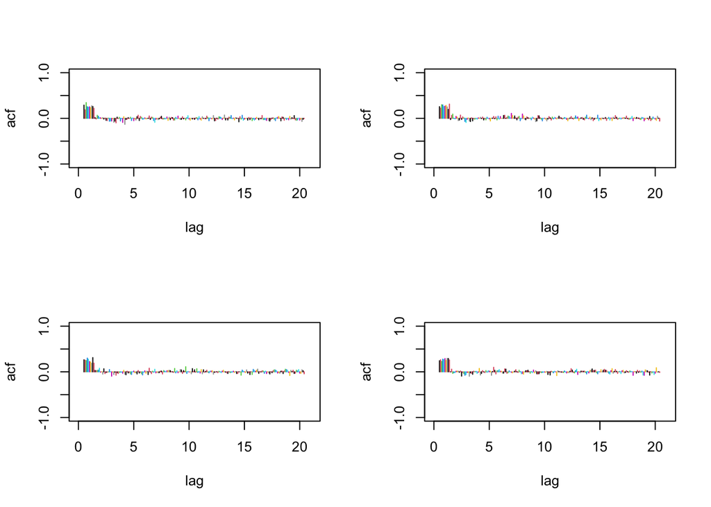

```r
# First for bartmod0, one panel for each chain
par(mfrow = c(2, 2))

auto.corr <- acf(bartmod0$yhat.train[ , sample(1:dim(dat)[1], 10), 1],
                 plot = FALSE)
max.lag <- max(auto.corr$lag[ , 1, 1])

j <- seq(-0.5, 0.4, length.out = 10)
for (h in 1:10) {
  if (h == 1) {
    plot(1:max.lag + j[h], auto.corr$acf[1 + (1:max.lag), h, h],
         type = 'h', xlim = c(0, max.lag + 1), ylim = c(-1, 1),
         ylab = 'acf', xlab = 'lag')
  } else {
    lines(1:max.lag + j[h], auto.corr$acf[1 + (1:max.lag), h, h],
          type = 'h', col = h)
  }
}

auto.corr <- acf(bartmod0$yhat.train[ , sample(1:dim(dat)[1], 10), 2],
                 plot = FALSE)
max.lag <- max(auto.corr$lag[ , 1, 1])

j <- seq(-0.5, 0.4, length.out = 10)
for (h in 1:10) {
  if (h == 1) {
    plot(1:max.lag + j[h], auto.corr$acf[1 + (1:max.lag), h, h],
         type = 'h', xlim = c(0, max.lag + 1), ylim = c(-1, 1),
         ylab = 'acf', xlab = 'lag')
  } else {
    lines(1:max.lag + j[h], auto.corr$acf[1 + (1:max.lag), h, h],
          type = 'h', col = h)
  }
}

auto.corr <- acf(bartmod0$yhat.train[ , sample(1:dim(dat)[1], 10), 3],
                 plot = FALSE)
max.lag <- max(auto.corr$lag[ , 1, 1])

j <- seq(-0.5, 0.4, length.out = 10)
for (h in 1:10) {
  if (h == 1) {
    plot(1:max.lag + j[h], auto.corr$acf[1 + (1:max.lag), h, h],
         type = 'h', xlim = c(0, max.lag + 1), ylim = c(-1, 1),
         ylab = 'acf', xlab = 'lag')
  } else {
    lines(1:max.lag + j[h], auto.corr$acf[1 + (1:max.lag), h, h],
          type = 'h', col = h)
  }
}

auto.corr <- acf(bartmod0$yhat.train[ , sample(1:dim(dat)[1], 10), 4],
                 plot = FALSE)
max.lag <- max(auto.corr$lag[ , 1, 1])

j <- seq(-0.5, 0.4, length.out = 10)
for (h in 1:10) {
  if (h == 1) {
    plot(1:max.lag + j[h], auto.corr$acf[1 + (1:max.lag), h, h],
         type = 'h', xlim = c(0, max.lag + 1), ylim = c(-1, 1),
         ylab = 'acf', xlab = 'lag')
  } else {
    lines(1:max.lag + j[h], auto.corr$acf[1 + (1:max.lag), h, h],
          type = 'h', col = h)
  }
}
```

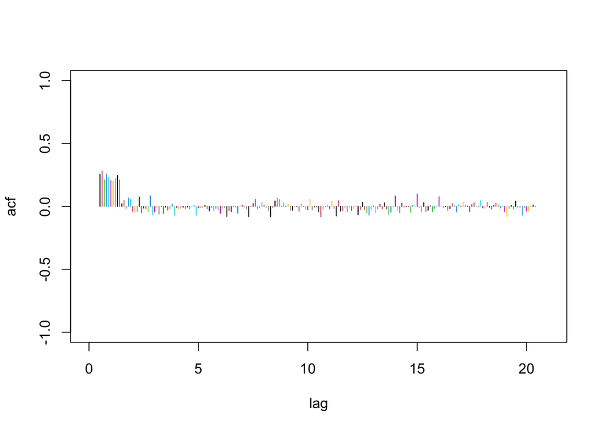

```r
# Then for bartmod1
auto.corr <- acf(bartmod1$yhat.train[ , sample(1:dim(dat)[1], 10), 1],
                 plot = FALSE)
max.lag <- max(auto.corr$lag[ , 1, 1])

j <- seq(-0.5, 0.4, length.out = 10)
for (h in 1:10) {
  if (h == 1) {
    plot(1:max.lag + j[h], auto.corr$acf[1 + (1:max.lag), h, h],
         type = 'h', xlim = c(0, max.lag + 1), ylim = c(-1, 1),
         ylab = 'acf', xlab = 'lag')
  } else {
    lines(1:max.lag + j[h], auto.corr$acf[1 + (1:max.lag), h, h],
          type = 'h', col = h)
  }
}
```

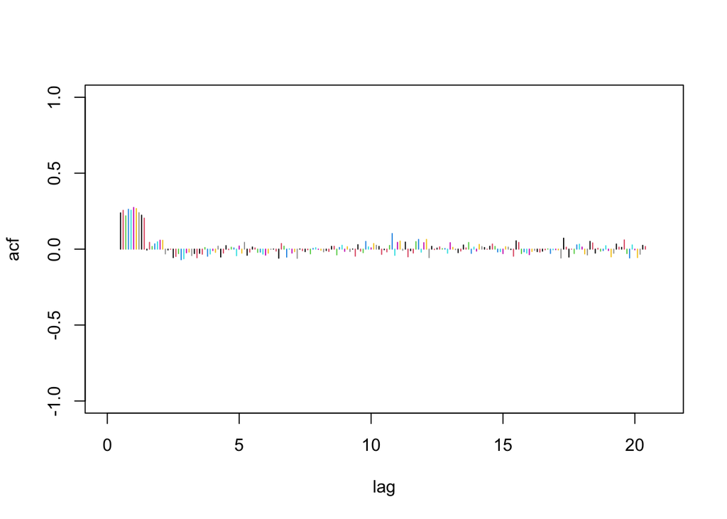

```r
auto.corr <- acf(bartmod1$yhat.train[ , sample(1:dim(dat)[1], 10), 2],
                 plot = FALSE)
max.lag <- max(auto.corr$lag[ , 1, 1])

j <- seq(-0.5, 0.4, length.out = 10)
for (h in 1:10) {
  if (h == 1) {
    plot(1:max.lag + j[h], auto.corr$acf[1 + (1:max.lag), h, h],
         type = 'h', xlim = c(0, max.lag + 1), ylim = c(-1, 1),
         ylab = 'acf', xlab = 'lag')
  } else {
    lines(1:max.lag + j[h], auto.corr$acf[1 + (1:max.lag), h, h],
          type = 'h', col = h)
  }
}
```

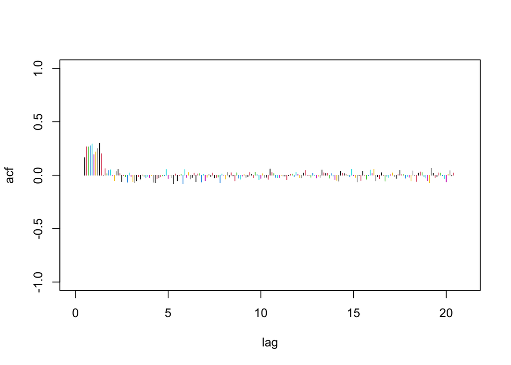

```r
auto.corr <- acf(bartmod1$yhat.train[ , sample(1:dim(dat)[1], 10), 3],
                 plot = FALSE)
max.lag <- max(auto.corr$lag[ , 1, 1])

j <- seq(-0.5, 0.4, length.out = 10)
for (h in 1:10) {
  if (h == 1) {
    plot(1:max.lag + j[h], auto.corr$acf[1 + (1:max.lag), h, h],
         type = 'h', xlim = c(0, max.lag + 1), ylim = c(-1, 1),
         ylab = 'acf', xlab = 'lag')
  } else {
    lines(1:max.lag + j[h], auto.corr$acf[1 + (1:max.lag), h, h],
          type = 'h', col = h)
  }
}
```

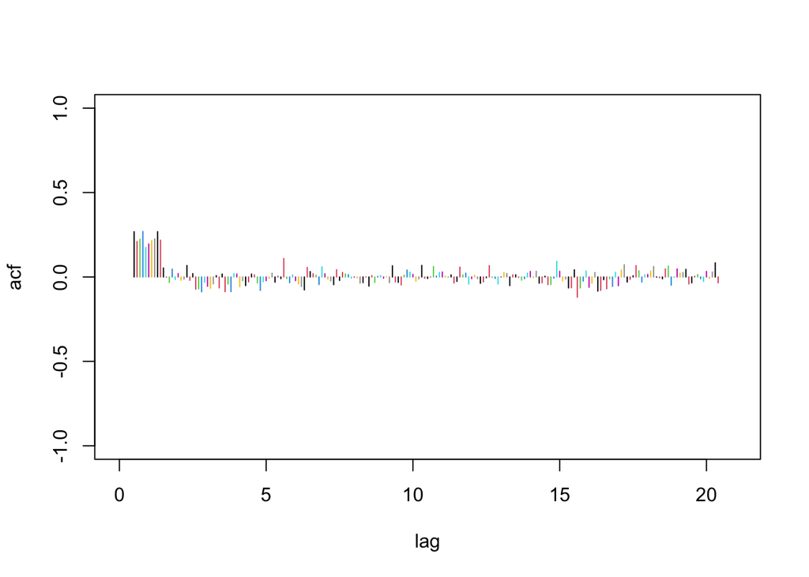

```r
auto.corr <- acf(bartmod1$yhat.train[ , sample(1:dim(dat)[1], 10), 4],
                 plot = FALSE)
max.lag <- max(auto.corr$lag[ , 1, 1])

j <- seq(-0.5, 0.4, length.out = 10)
for (h in 1:10) {
  if (h == 1) {
    plot(1:max.lag + j[h], auto.corr$acf[1 + (1:max.lag), h, h],
         type = 'h', xlim = c(0, max.lag + 1), ylim = c(-1, 1),
         ylab = 'acf', xlab = 'lag')
  } else {
    lines(1:max.lag + j[h], auto.corr$acf[1 + (1:max.lag), h, h],
          type = 'h', col = h)
  }
}
```

Next, we plot the Geweke Z statistics for each individual, which should be approximately distributed as a standard Normal.

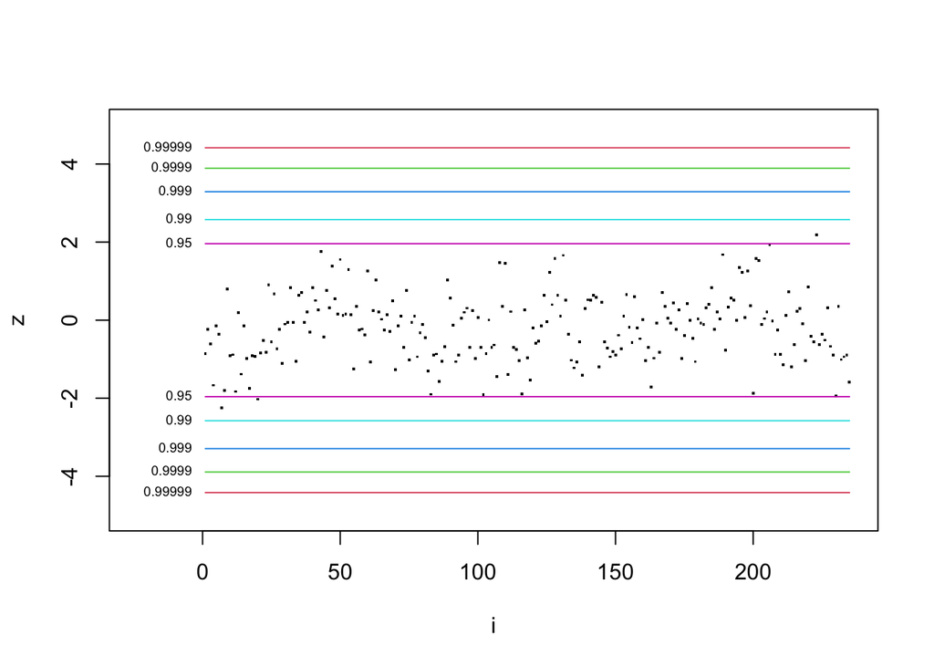

```r
# First for bartmod0
geweke <- gewekediag(bartmod0$yhat.train.collapse)
n <- dim(dat)[1]
j <- -10^(log10(n) - 1)
plot(geweke$z, pch = '.', cex = 2, ylab = 'z', xlab = 'i',
     xlim=c(j, n), ylim=c(-5, 5))
lines(1:n, rep(-1.96, n), type='l', col=6)
lines(1:n, rep(+1.96, n), type='l', col=6)
lines(1:n, rep(-2.576, n), type='l', col=5)
lines(1:n, rep(+2.576, n), type='l', col=5)
lines(1:n, rep(-3.291, n), type='l', col=4)
lines(1:n, rep(+3.291, n), type='l', col=4)
lines(1:n, rep(-3.891, n), type='l', col=3)
lines(1:n, rep(+3.891, n), type='l', col=3)
lines(1:n, rep(-4.417, n), type='l', col=2)
lines(1:n, rep(+4.417, n), type='l', col=2)
text(c(1, 1), c(-1.96, 1.96), pos=2, cex=0.6, labels='0.95')
text(c(1, 1), c(-2.576, 2.576), pos=2, cex=0.6, labels='0.99')
text(c(1, 1), c(-3.291, 3.291), pos=2, cex=0.6, labels='0.999')
text(c(1, 1), c(-3.891, 3.891), pos=2, cex=0.6, labels='0.9999')
text(c(1, 1), c(-4.417, 4.417), pos=2, cex=0.6, labels='0.99999')
```

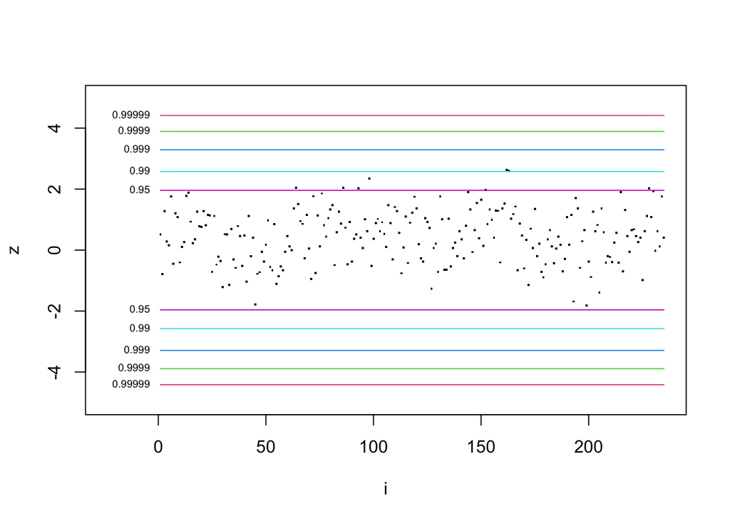

```r
# Then for bartmod1
geweke <- gewekediag(bartmod1$yhat.train.collapse)
plot(geweke$z, pch = '.', cex = 2, ylab = 'z', xlab = 'i',
     xlim=c(j, n), ylim=c(-5, 5))
lines(1:n, rep(-1.96, n), type='l', col=6)
lines(1:n, rep(+1.96, n), type='l', col=6)
lines(1:n, rep(-2.576, n), type='l', col=5)
lines(1:n, rep(+2.576, n), type='l', col=5)
lines(1:n, rep(-3.291, n), type='l', col=4)
lines(1:n, rep(+3.291, n), type='l', col=4)
lines(1:n, rep(-3.891, n), type='l', col=3)
lines(1:n, rep(+3.891, n), type='l', col=3)
lines(1:n, rep(-4.417, n), type='l', col=2)
lines(1:n, rep(+4.417, n), type='l', col=2)
text(c(1, 1), c(-1.96, 1.96), pos=2, cex=0.6, labels='0.95')
text(c(1, 1), c(-2.576, 2.576), pos=2, cex=0.6, labels='0.99')
text(c(1, 1), c(-3.291, 3.291), pos=2, cex=0.6, labels='0.999')
text(c(1, 1), c(-3.891, 3.891), pos=2, cex=0.6, labels='0.9999')
text(c(1, 1), c(-4.417, 4.417), pos=2, cex=0.6, labels='0.99999')
```

```r
# If several points lie beyond the dark blue line or further, consider using more thinning (larger keepevery parameter) when fitting the models.
```